# Assessing Coral Recovery and Reassembly in the Great Barrier Reef

STAT3926: Statistical Consulting

Authors

Prepared by: Bodhi McNally

Prepared for: Ana Paula da Silva PhD

Published

June 3, 2024

## 2 Background

While considerable research has focused on the factors influencing the recovery rates of coral reef communities, less attention has been paid to the various aspects of the recovery process itself (Bellwood et al. 2004; Hughes et al. 2010; Graham, Nash, and Kool 2011). Recovery of coral reefs encompasses multiple components. The return of hard coral cover to pre-disturbance levels, referred to as ‘coral recovery,’ is the most widely used metric for assessing the recovery of coral communities (Hughes et al. 2010; Graham, Nash, and Kool 2011). ‘Reassembly’ pertains to the recovery of coral community composition, ensuring that the relative abundances of component taxa resemble pre-disturbance levels. Reassembly is crucial for restoring the processes and traits that contribute to the ecosystem function of a coral community (Moberg and Folke 1999; Nystrom et al. 2008). However, compositional shifts can result in the loss of function and subsequent reef ecosystem degradation.

## 3 Client’s Aims

The client aims to investigate recovery times among different coral morphologies and determine the factors influencing the successful reassembly of coral communities. Specifically, the objectives are:

1. To analyse the recovery times of various coral morphologies across different regions and shelf locations.
2. To determine whether reefs that successfully recover also reassemble to have the same distribution of morphologies.
3. To evaluate the impact of environmental factors such as region, shelf location, and recovery time on the likelihood of successful reassembly.
4. To investigate the role of different coral morphologies in driving successful reassembly.
5. To forecast the number of coral cover disturbances using SST as the predictor.

## 4 Analysis

Relative changes in coral cover are calculated year-on-year for the coral morphologies. This helps identify significant changes in coral cover over time. Significant changes in coral cover are identified by comparing the relative change to twice the standard deviation of the changes. This helps flag significant deviations from the mean change.

### 4.1 Recovery Times for Coral Morphologies Across Regions and Shelves

A function is defined to compute the years taken for coral cover to return to pre-disturbance levels. An ANOVA is performed to test for differences in recovery times across coral types and shelves.

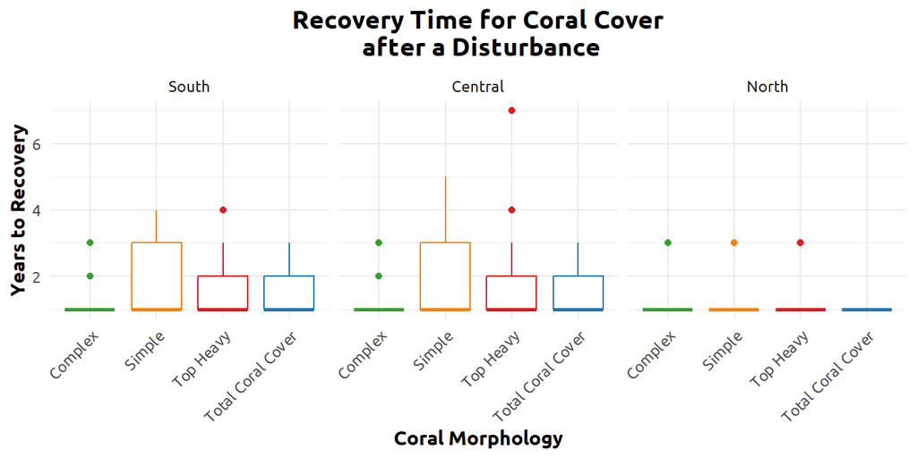

Figure 1: The boxplots display the number of years to recovery for three coral morphologies: Complex, Simple, Top Heavy, and Total Coral Cover, across three regions of the GBR: South, Central, and North. Each boxplot represents the distribution of recovery times, with the median indicated by a horizontal line inside the box, the interquartile range represented by the height of the box, and any outliers shown as individual points.

Referring to Figure 1, the median time for all coral morphologies and total coral cover to recover to its pre-disturbance level was one year. Simple coral morphologies in the Southern and Central regions exhibited the broadest distribution of recovery times, with some reefs taking up to five years to fully recover. In the Northern region, most reefs recovered within one year.

The Wilcoxon rank sum test results (Table 1) indicate that both coral type, region and shelf location have significant effects on recovery time (p < $0.05$).

### 4.2 Coral Reassembly Analysis Using Bray-Curtis Similarity

The coral assemblage in the year immediately prior to the disturbance was taken as the reference point. To assess changes in the composition of coral communities during recovery, the cover of coral morphologies was transformed to relative abundance so that the sum of all coral components was 100%. A Bray–Curtis similarity (Equation 1) matrix for each reef was produced to compare pre-disturbance coral communities with those in each year of recovery.

To account for natural variation in composition, we calculated a ‘reassembly benchmark’ as the average Bray–Curtis similarity between coral communities in the years prior to the first disturbance (some reefs experienced multiple disturbances).

If a reef’s Bray-Curtis similarity was greater than the benchmark for that reef, it was marked as successful. Logistic regression was then used to evaluate the significance of Region, Shelf, and time taken for coral recovery on the likelihood of successful reassembly.

The average proportion of successful reassemblies across the entire reef system is 0.83. By region, the proportion of successful reassemblies was 0.88, 0.8 and 0.8 for the Southern, Central and Northern regions, respectively. The mean reassembly benchmark was 80%, with a range of 70 - 90%.

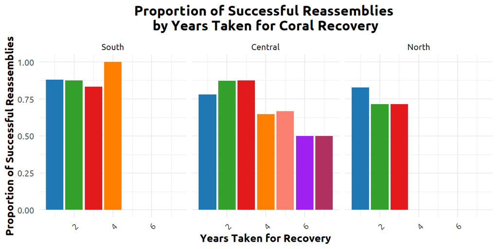

Figure 2: The bar plots illustrate the proportion of successful coral reassemblies in relation to the number of years taken for recovery across three regions of the GBR: South, Central and North. Each bar represents the proportion of reefs that successfully reassembled after recovery periods of between 1 and 7 years.

### 4.3 Morphological Drivers of Successful Coral Reassembly

We employed logistic regression analysis to assess the influence of coral morphologies on the likelihood of successful reassembly. By fitting a logistic regression model, we evaluated whether the proportions of Simple and Complex coral types significantly predict successful reassembly.

The logistic regression model (Table 4) indicates that neither the relative abundance of Simple (p = $0.624$) nor Complex corals (p = $0.156$) significantly predicts the probability of successful reassembly.

### 4.4 Modelling Coral Cover Disturbances and Sea Surface Temperature

Three models (linear regression, polynomial regression and a generalised additive model) were fitted to the data to explore the relationship between the number of annual coral cover disturbances and average annual SST. AIC and BIC were employed to determine the best-fitting model. Future SST predictions were obtained from climate projections under two Representative Concentration Pathways (RCP 4.5 and RCP 8.5). The historical average SST was calculated and future SST values were estimated by adding the projected SST increases to the historical average. Future disturbances were predicted for 2030 and 2090 under both RCP scenarios.

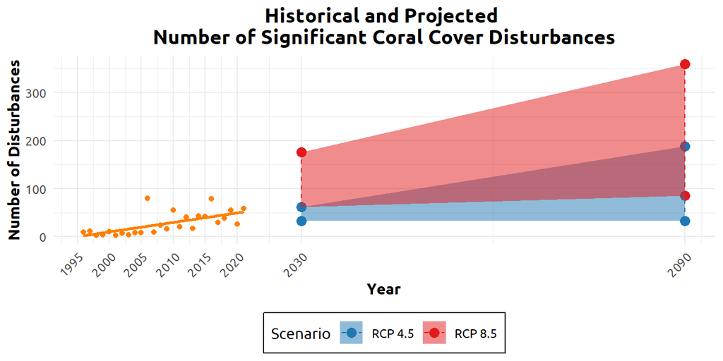

Using the GAM, Figure 3 show that the number of significant coral cover disturbances in the GBR is projected to rise under RCP 4.5 and 8.5 pathways. This increase in disturbances is particularly pronounced under the RCP 8.5 scenario, which assumes minor curbing of emissions. Although our analysis has shown that many reefs have historically demonstrated the ability to recover and, to a lesser extent, successfully reassemble to their pre-disturbance states, the increasing frequency and severity of disturbances pose a significant threat to their resilience. Repeated disturbances may compromise the reefs’ ability to recover and reassemble overtime..

## 5 Limitations

One significant limitation is the reliance on morphological data without sufficient species-level data. While morphological data provide insights, species-level data could reveal the taxa that drive recovery post-disturbance.

Focusing solely on thermal stress as the primary environmental stressor is another limitation. Coral reefs are also affected by pollution, overfishing, and ocean acidification, which were not considered due to project timeline constraints.

Further, the current analysis’s broad scope may overlook specific local variations and unique reef characteristics. Interdisciplinary consultation with marine scientists can help isolate specific reefs or communities for detailed study. This targeted approach could reveal unique recovery and reassembly patterns.

Additionally, the analysis could benefit from mapping coral recovery and reassembly with other biotic agents, such as fish populations. Coral reefs are complex ecosystems where recovery is linked to the health of other species. Integrating data on biotic agents would provide a more holistic view of ecosystem recovery, reveal critical interdependencies, and increase the research’s value.

## 6 Personal Reflection

This semester’s consulting projects highlighted the importance of being a generalist in statistical consulting. I encountered statistical concepts and tools not covered in my studies. My background in data science allowed me to address a wide range of problems by leveraging foundational knowledge and seeking additional expertise. Consulting with the academics was crucial for gaining insights into advanced techniques necessary for the clients’ needs. This experience emphasised the value of a flexible and expansive knowledge base, enabling me to tackle new challenges confidently and resourcefully.

## 7 Appendix

### 7.1 Bray-Curtis Similarity Metric

The Bray-Curtis similarity metric is a measure of similarity between two samples based on their composition. It is commonly used in ecological studies to compare the species composition of different sites. The Bray-Curtis similarity ranges from 0 to 1, where 0 indicates no similarity and 1 indicates complete similarity.

The formula for Bray-Curtis similarity $BC_{ij}$ between two samples $i$ and $j$ is given by:

$$BC_{ij} = 1 - \frac{\sum_{k=1}^n |x_{ik} - x_{jk}|}{\sum_{k=1}^n (x_{ik} + x_{jk})}
\tag{1}$$

The Bray-Curtis similarity metric takes into account the differences in species abundances between two samples and is particularly sensitive to changes in the presence or absence of species. This makes it a useful metric for assessing ecological reassembly, as it provides insight into how closely a recovering community resembles its pre-disturbance state.

### 7.2 Wilcoxon Rank Sum Test Results

Table 1: Wilcoxon Rank Sum Test Results

(a) Results

| Test | Chi-Squared | DF | P-Value |
| --- | --- | --- | --- |
| Coral_Type | 42.479184 | 3 | 0.0000000 |
| SHELF | 7.928779 | 2 | 0.0189796 |
| REGION | 38.451741 | 2 | 0.0000000 |

### 7.3 Logistic Regression Results for Recovery Time and Reassembly Success

Table 2: Logistic Regression Results

Logistic Regression Results

Model: Successful Reassembly ~ Years Taken + Region

| Term | Estimate | Std. Error | z Value | Pr(>\|z\|) |
| --- | --- | --- | --- | --- |
| (Intercept) | 1.537 | 0.234 | 6.569 | 0.000 |
| Years_Taken | −0.081 | 0.101 | −0.801 | 0.423 |
| REGIONNorth | −0.024 | 0.344 | −0.071 | 0.943 |
| REGIONSouth | 0.564 | 0.238 | 2.366 | 0.018 |

### 7.4 Logistic Regression for Spatial Predictors of Reassembly Success

Table 3: Logistic Regression Results

Logistic Regression Results

Model: Successful Reassembly ~ Region + Shelf

| Term | Estimate | Std. Error | z Value | Pr(>\|z\|) |
| --- | --- | --- | --- | --- |
| (Intercept) | 0.913 | 0.292 | 3.122 | 0.002 |
| REGIONNorth | −0.054 | 0.344 | −0.158 | 0.875 |
| REGIONSouth | 0.436 | 0.248 | 1.755 | 0.079 |
| SHELFM | 0.462 | 0.331 | 1.398 | 0.162 |
| SHELFO | 0.857 | 0.365 | 2.349 | 0.019 |

### 7.5 Morphological Drivers of Successful Reassembly Logistic Regression Results

Table 4: Logistic Regression Results

Logistic Regression Results

| Term | Estimate | Std. Error | z Value | Pr(>\|z\|) |
| --- | --- | --- | --- | --- |
| (Intercept) | 2.060 | 0.526 | 3.910 | 0.000 |
| Simple.x | −0.003 | 0.007 | −0.490 | 0.624 |
| Complex.x | −0.014 | 0.010 | −1.420 | 0.156 |

The effect of top-heavy corals are implicitly captured since the sum of the three variables is 100%.

### 7.6 AIC and BIC

Table 5: AIC Values for Model Comparison

| Model | Df | AIC |
| --- | --- | --- |
| linear_model | 3.000000 | 239.0016 |
| poly_model | 4.000000 | 239.1865 |
| gam_model | 4.889002 | 236.9952 |

Table 6: BIC Values for Model Comparison

| Model | Df | BIC |
| --- | --- | --- |
| linear_model | 3.000000 | 242.7759 |
| poly_model | 4.000000 | 244.2189 |
| gam_model | 4.889002 | 243.1460 |

## References

Bellwood, David R, Terry P Hughes, Carl Folke, and Magnus Nystrom. 2004. “Confronting the Coral Reef Crisis.” *Nature* 429: 827–33.

Graham, Nicholas A J, Kirsty L Nash, and Julian T Kool. 2011. “Coral Reef Recovery Dynamics in a Changing World.” *Coral Reefs* 30: 283–94.

Hughes, Terry P, Nicholas A J Graham, Jeremy B C Jackson, Peter J Mumby, and Robert S Steneck. 2010. “Rising to the Challenge of Sustaining Coral Reef Resilience.” *Trends in Ecology & Evolution* 25: 633–42.

Moberg, Fredrik, and Carl Folke. 1999. “Ecological Goods and Services of Coral Reef Ecosystems.” *Ecological Economics* 29: 215–33.

Nystrom, Magnus, Nicholas A J Graham, Jonas Lokrantz, and Albert V Norstrom. 2008. “Capturing the Cornerstones of Coral Reef Resilience: Linking Theory to Practice.” *Coral Reefs* 27: 795–809.